# Operating Model Specification Report for e.g. Atlantic swordfish

Demonstration evaluation analysis

Alex Doe (a.doe@gmail.com)

2018-05-29

# 1 About this document

This is a prototype of an automatic report that documents how the user specified the operating model and their various justifications.

# 2 Fishery Characteristics

## 2.1 Longevity

Selected:

- Moderately long-lived (0.1 < M < 0.2)

No justification was provided

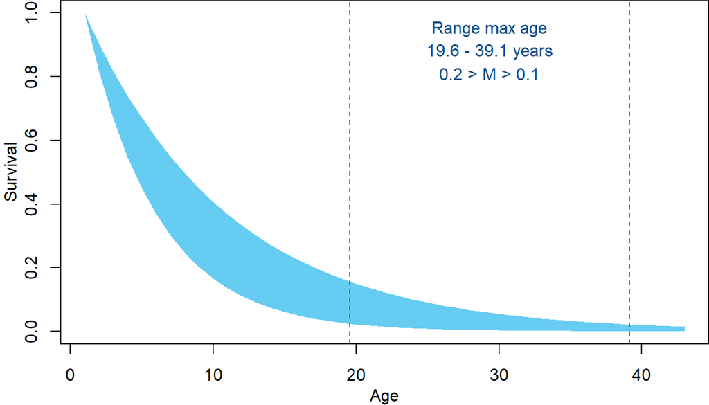

## 2.2 Depletion

Selected:

- Moderately depleted (0.2 < D < 0.3)
- Healthy (0.3 < D < 0.6)

No justification was provided

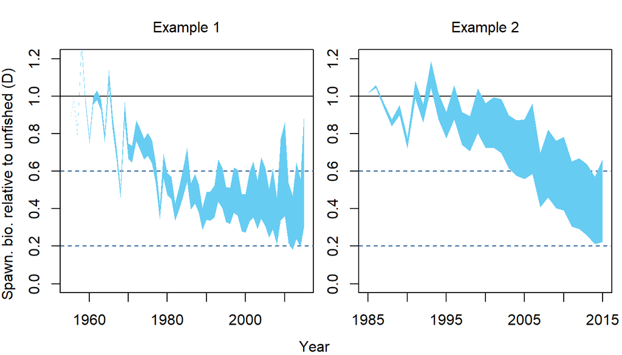

## 2.3 Resilence

Selected:

- Moderate resilence (0.5 < h < 0.7)

No justification was provided

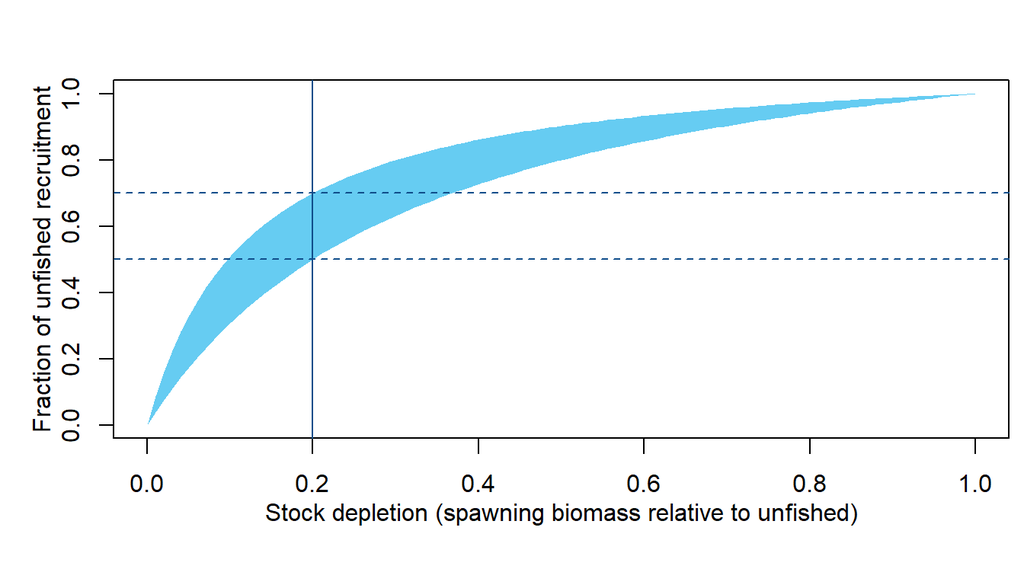

## 2.4 Pattern of historical exploitation

Selected:

- Boom-bust
- Gradual increases

No justification was provided

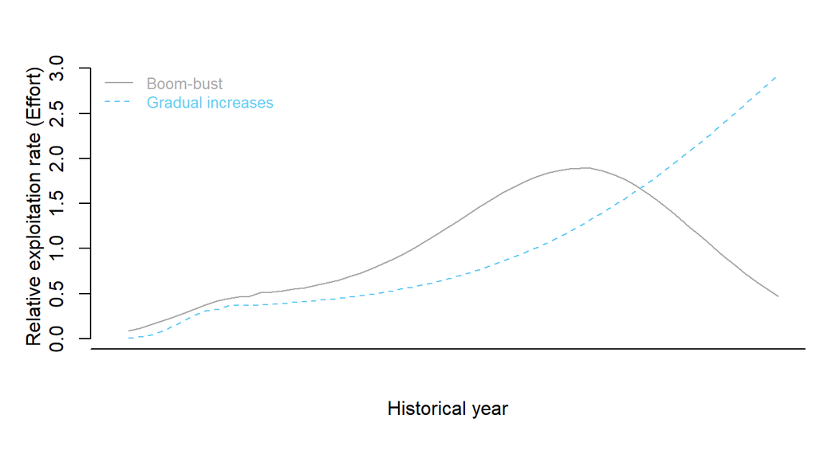

## 2.5 Variability in historical exploitation

Selected:

- Variable (10% < CV < 25%)

No justification was provided

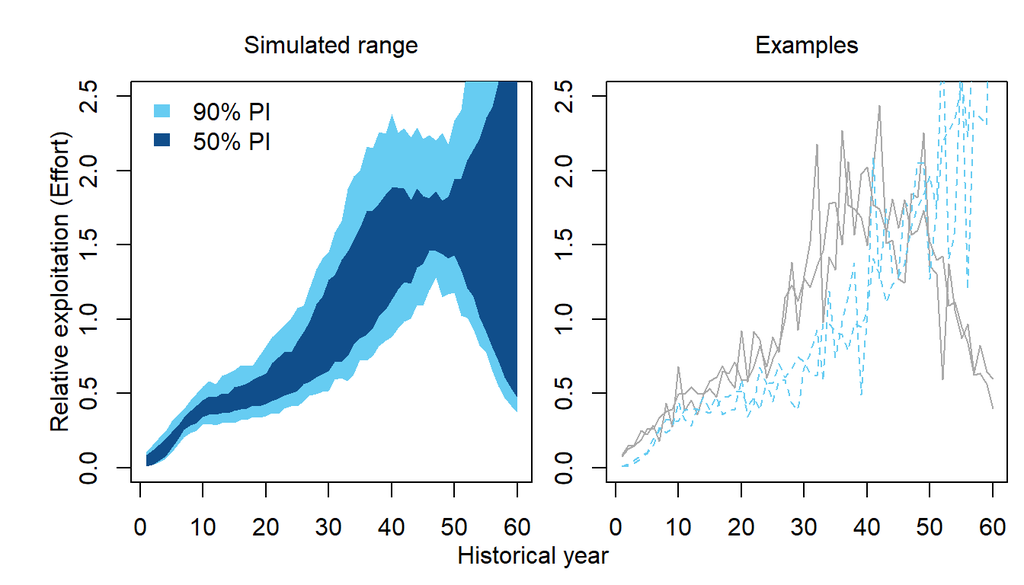

## 2.6 Fishery selectivity relative to maturity

Selected:

- Small (0.5 < S < 0.75)
- Similar to maturity (0.75 < S < 1.25)
- Large (1.25 < S < 1.5)

No justification was provided

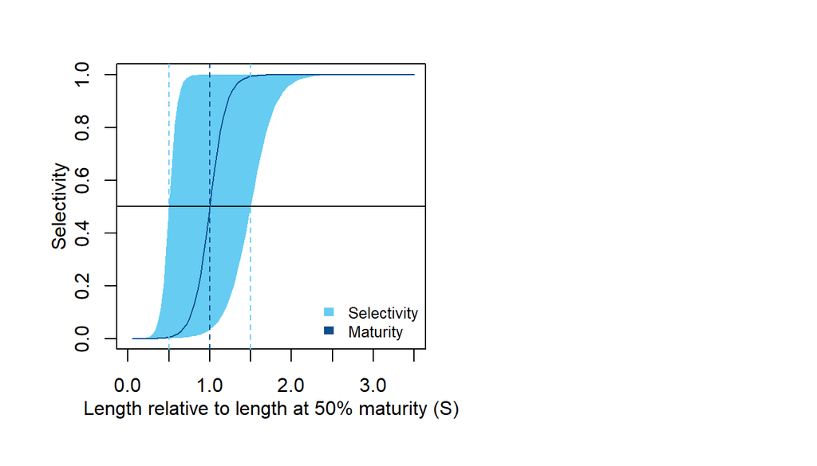

## 2.7 Vulnerability of large individuals

Selected:

- Declining selectivity with length (0.75 < SL < 1)

No justification was provided

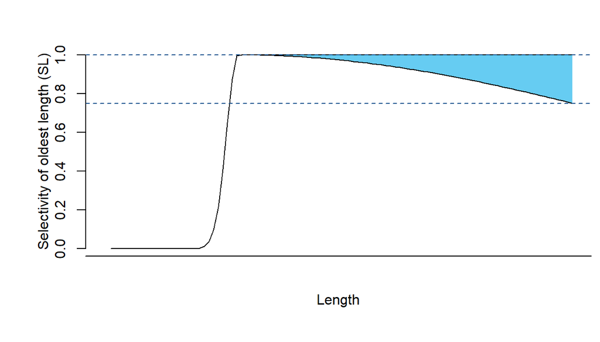

## 2.8 Discard rate

Selected:

- Low (DR < 1%)
- Low - moderate (1% < DR < 10%)

No justification was provided

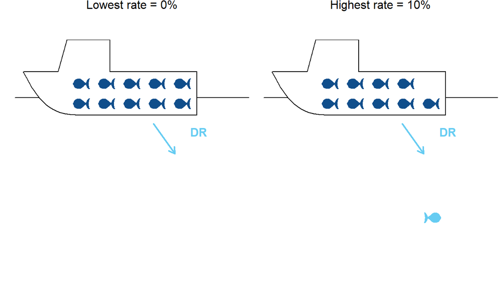

## 2.9 Post-release mortality rate

Selected:

- Low (PRM < 5%)

No justification was provided

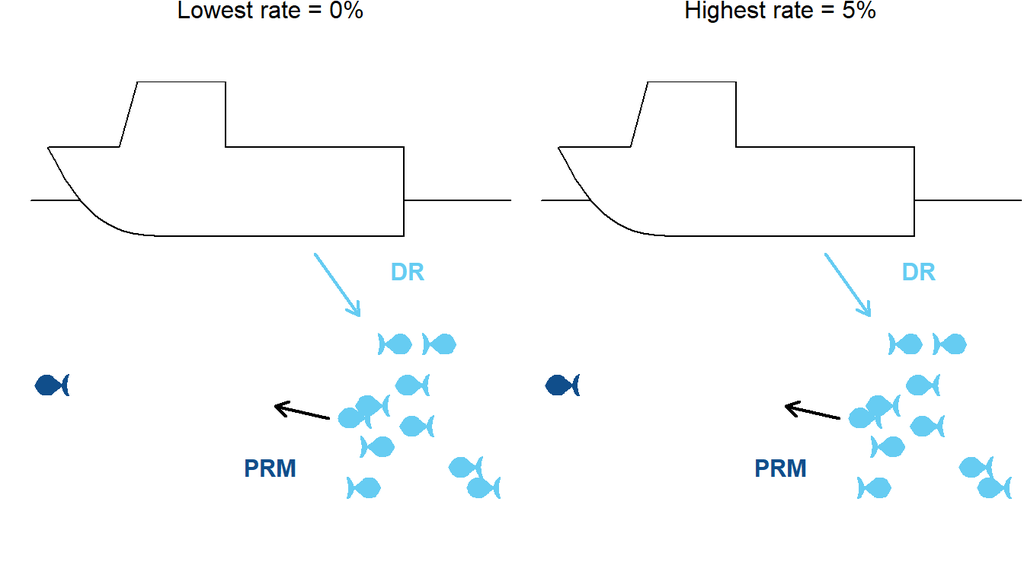

## 2.10 Recruitment variability

Selected:

- Low (0.1 < sigma R < 0.3)

No justification was provided

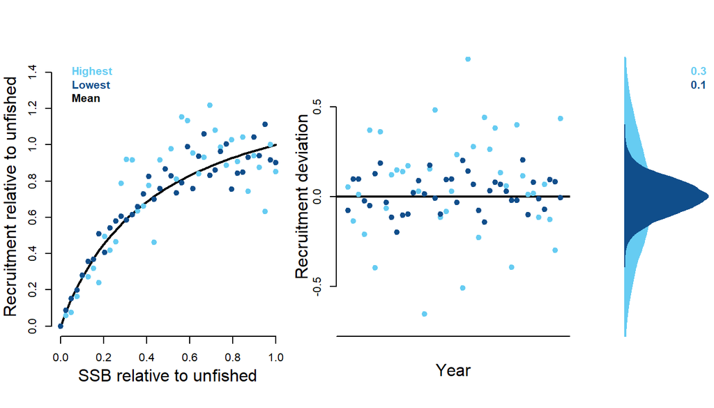

## 2.11 Changes in fishing efficiency

Selected:

- Stable -1% to 1% pa (may halve/double every 70 years)

No justification was provided

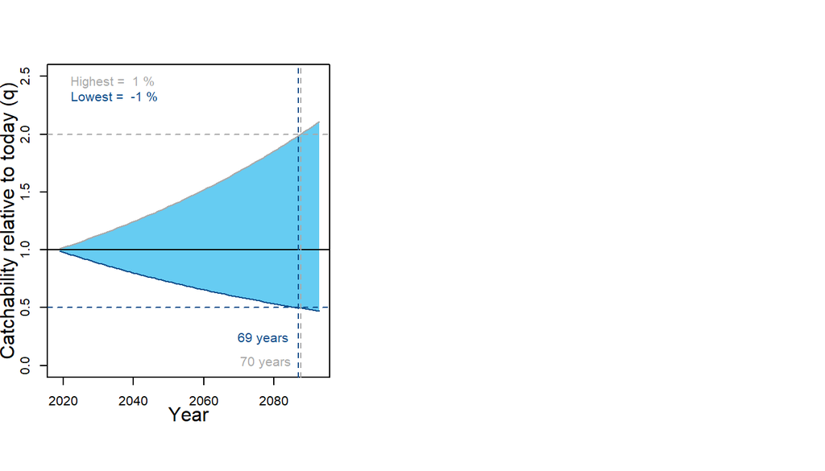

## 2.12 Size of an prospective marine reserve

Selected:

- None

No justification was provided

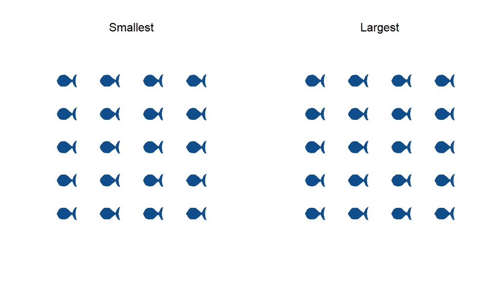

## 2.13 Stock viscosity (movement in/out of marine reserve)

Selected:

- Moderate (5% < P < 10%)
- High (10% < P < 20%)

No justification was provided

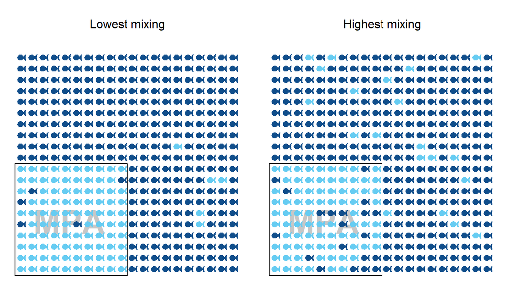

# 3 Management Characteristics

## 3.1 Types of fishery management that are possible

Selected:

- TAC (Total Allowable Catch): a catch limit
- TAE (Total Allowable Effort): an effort limit
- Size limit
- Time-area closures (a marine reserve)

No justification was provided

## 3.2 Implementation uncertainty: consistent overages/underages

Selected:

- Taken exactly (95% - 105% of recommended)

No justification was provided

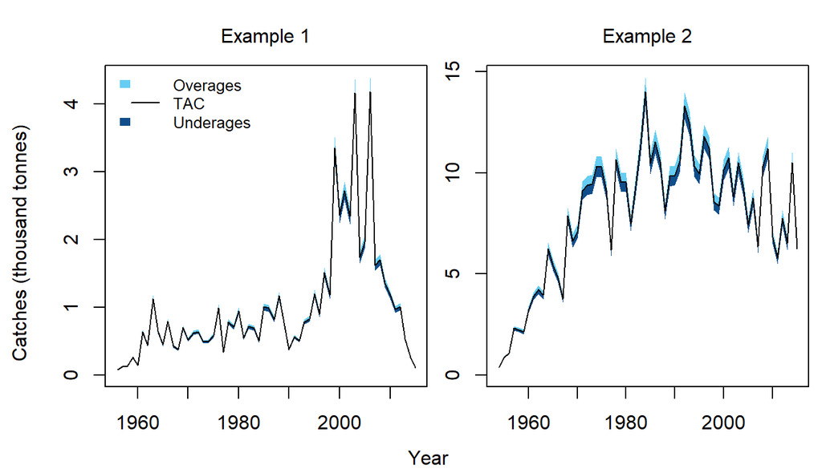

## 3.3 Implementation uncertainty: variability

Selected:

- Not variable (1% < V < 5%)

No justification was provided

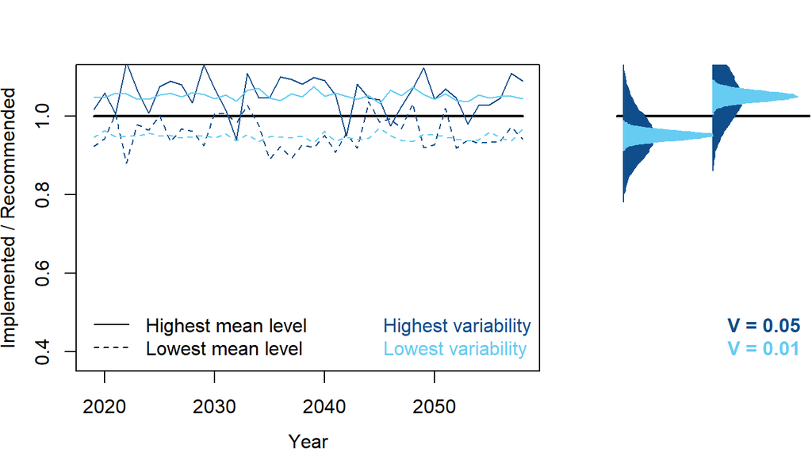

# 4 Data Characteristics

## 4.1 Available data types

Selected:

- Historical annual catches (from unfished)
- Recent annual catches (at least 5 recent years)
- Historical relative abundance index (from unfished)
- Recent relative abundance index (at least 5 recent years)
- Fishing effort
- Size composition (length samples)
- Age composition (age samples)
- Growth (growth parameters)
- Current biomass survey

No justification was provided

## 4.2 Catch reporting bias

Selected:

- Reported accurately (+/- 5%)

No justification was provided

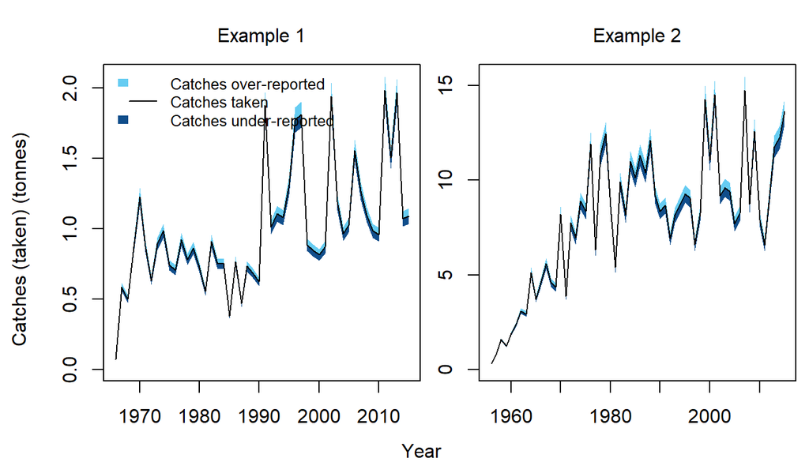

## 4.3 Hyperstability in indices

Selected:

- Proportional (0.8 < Beta < 1.25)

No justification was provided

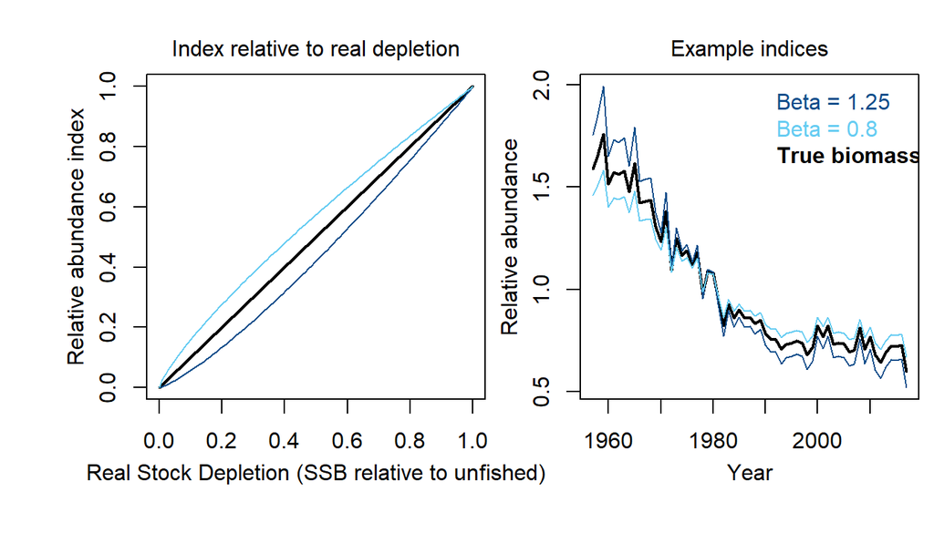

Selected:

- Good (accurate and precise)

No justification was provided

# 5 Version Notes

The package is subject to ongoing testing. If you find a bug or a problem please send a report to t.carruthers@oceans.ubc.ca so that it can be fixed!